# Does the Magic Hold Up? A Review Analysis of Harry Potter

Anna Ng

```r
library(tidyverse)
library(ggthemes)
```

# Introduction

Harry Potter is a series of seven fantasy novels written by British author J. K. Rowling. The novels chronicle the lives of a young wizard, Harry Potter, and his friends Hermione Granger and Ron Weasley, all of whom are students at Hogwarts School of Witchcraft and Wizardry. Since the release of the first novel, Harry Potter and the Philosopher’s Stone, on 26 June 1997, the books have found immense popularity and commercial success worldwide. Despite the controversies of its author, the series keeps attracting the interest of thousands of readers in the world, selling more than 600 million copies worldwide as of 2023.

I would be using the [Harry Potter Reviews Dataset](https://www.kaggle.com/datasets/marcpaulo/harry-potter-reviews) by Marc Paulo in Kaggle, which contains 491 synthetic reviews of the famous “Harry Potter and the Philosopher’s Stone” movie. The reviews were generated using a LLM (Large Language Model).

There are 8 variables in the dataset:

- *user_id:* An id generated for each user who gave a review.
- *user_sex (later renamed to “user_gender”):* Female, male or other.
- *user_age:* The user’s age.
- *user_country:* The user’s country. It is important to notice they are all European countries.
- *rating:* Rating given by the user in a scale of 1 to 5.
- *comment:* A comment left by the user regarding the movie.
- *favourite_character:* The user’s favorite character from the movie.
- *date:* The date data was collected. Between 2001 and 2005.

Despite how the series touches very dark topics like death and murder, the fantasy and magic surrounding the Wizarding World suggar coats the story and gives the wrong impresion of it being a kids series. This analysis aims to check if younger people who identified themselves as females were more likely to leave a good review.

The dataset was cleaned before the analysis, which consisted of renaming the user_sex variable to user_gender.

```r
harry_potter_reviews_cleaned
```

```
## # A tibble: 491 × 8
##    user_id user_gender user_age user_country rating comment  favourite_character
##      <dbl> <chr>          <dbl> <chr>         <dbl> <chr>    <chr>
##  1       0 female            50 Germany         2.5 "\"The … Severus Snape
##  2       1 female            23 Spain           4   "\"Seve… Severus Snape
##  3       2 male              32 France          3   "\"The … Ron Weasley
##  4       3 female            24 Turkey          4.5 "\"Hagr… Rubeus Hagrid
##  5       4 female            40 Spain           5   "\"Nevi… Neville Longbottom
##  6       5 female            16 Finland         5   "\"Rube… Rubeus Hagrid
##  7       6 male              26 Germany         4   "\"Seve… Severus Snape
##  8       7 female            28 Sweden          2.5 "\"Albu… Albus Dumbledore
##  9       8 female            52 Switzerland     4   "\"Ron … Ron Weasley
## 10       9 female            46 Turkey          4.5 "\"Herm… Hermione Granger
## # ℹ 481 more rows
## # ℹ 1 more variable: date <date>
```

# Analysis

## Graph 1

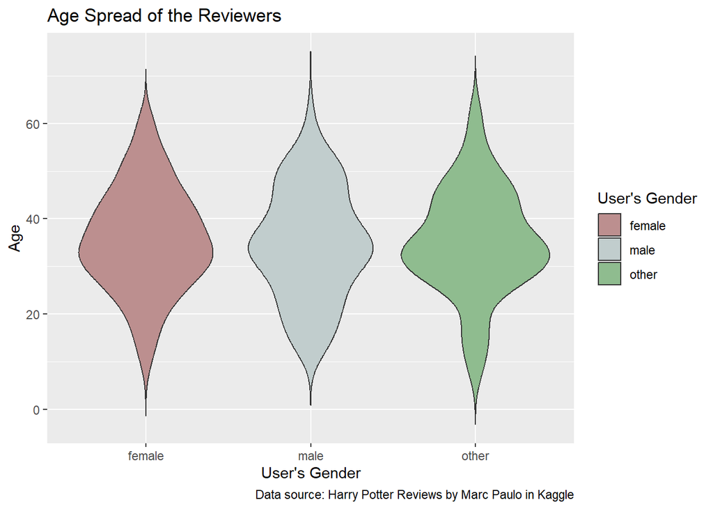

```r
#Violin Plot
ggplot(harry_potter_reviews_cleaned, aes(x = user_gender, y = user_age, fill = user_gender)) +
  geom_violin(trim = FALSE) +
  scale_fill_manual(values = c("rosybrown", "azure3", "darkseagreen")
  ) +
   labs(
    title = "Age Spread of the Reviewers",
    caption = "Data source: Harry Potter Reviews by Marc Paulo in Kaggle",
   x = "User's Gender",
   y = "Age",
   fill = "User's Gender"
  )
```

Graph 1 uses a violin graph to describe the age distribution of all genders. The x-axis shows the user’s gender and the y-axis the user’s age. For all genders, the distribution of age seemed similar with most of the users having between 20 and 50 years old. The distribution for both females and males was similar, while the others group had a more different shape, meaning a different distribution pattern. It is important to notice the fewer number of young users, while there is a higher number for older users.

## Graph 2

```r
female_rating <- harry_potter_reviews_cleaned |>
  filter(user_gender == "female") |>
  mutate(
    age_group = case_when(
      user_age < 20 ~ "Under 20",
      user_age < 30 ~ "20-29",
      user_age < 40 ~ "30-39",
      user_age < 50 ~ "40-49",
      user_age < 60 ~ "50-59",
      TRUE ~ "60+"
      )
  )
```

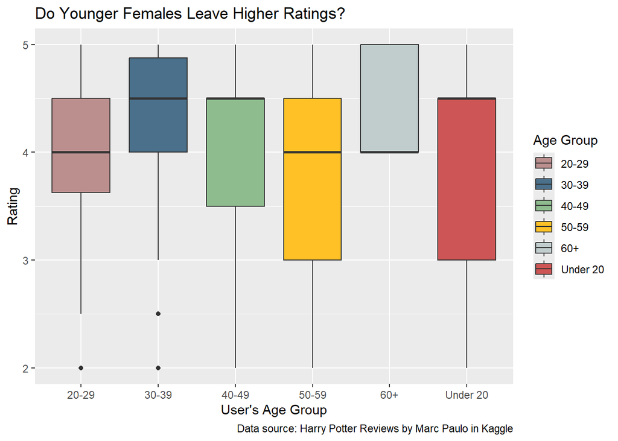

```r
#Boxplot
ggplot(female_rating, aes(x = age_group, y = rating, fill = age_group)) +
  geom_boxplot() +
  scale_fill_manual(values = c("rosybrown", "skyblue4", "darkseagreen", "goldenrod1", "azure3", "indianred3")) +
  labs(
    title = "Do Younger Females Leave Higher Ratings?",
    caption = "Data source: Harry Potter Reviews by Marc Paulo in Kaggle",
    x = "User's Age Group",
    y = "Rating",
    fill = "Age Group"
  )
```

Graph 2 uses a boxplot to display the relationship between female user’s age in the x-axis and the rating in the y-axis. The dataset was further cleaned to only show female users’ rating and their age group.

# Conclusion

The data suggests that the Harry Potter series(or at least the first movie) can be appealing to different demographics, not only younger females.

It is also important to note that stronger conclusions can be drawn with a more adequate testing, as the dataset used only had 491 entries exclusively from European countries. A large and more diverse sample with higher randomness could result in a more representative sample and, potentially, more generalizable results.